# Final Project

Shopping Festival Consumption Data Analysis

Hanyu  
5/9/2022

## Introduction

With the popular application of information technology and the rapid development of the Internet, e-commerce has gradually become a new model for people to conduct business activities. E-commerce makes the user establish contact with the chosen business through the computer or cell phone for fast and convenient transaction activities, while the business can market goods and services all over the country through the Internet website at a fairly low cost, and smoothly develop a global target market.

E-commerce is an important element of strategic emerging industries and modern circulation methods and is an important grasp and realization of science and technology and cultural innovation. The vigorous development of e-commerce has significantly helped to promote healthy economic and social development, expand consumer demand, and enhance the city’s high-end resource pooling, industrial chain restructuring, and technological innovation. Especially during the epidemic, the real economy suffered huge losses, and at this time, the advantages of e-commerce came out, with the advantages of high operational efficiency, low transaction costs and wide audience coverage, and the close integration of e-commerce with the logistics industry and technological, financial and cultural innovation. In recent years, the amount of Internet transactions in China has been maintaining the momentum of rapid development. As an important basic platform for China’s economic and social development, the Internet has further increased its influence on promoting national economic growth and the progress of social life. It has become the most active area in China’s social development today.

E-commerce platforms are oriented to consumer groups, and merchants, they need to differentiate between worthless consumers and high-value consumers through consumption data to gain more benefits. Consumers, also need to receive more personalized services to increase their experience and satisfaction. Therefore, the platform develops optimized personalized service plans for consumers with different values, and formulates corresponding marketing strategies for preference recommendation and promotion, focusing limited marketing resources on high-value consumers and providing personalized services to different consumers to achieve the goal of maximizing profits for the platform and merchants.

Based on this situation, this project analyzes the consumption data of the 11.11 shopping festival to achieve the following objectives.

1. Classify and analyze the sales of products with the help of Taobao Mall consumer data.
2. To analyze the characteristics of different consumers and compare the consumption value of different categories of consumers.
3. To study the consumption habits of different consumers in order to provide personalized services to different consumer categories.

## Data

### Read Data

```r
##Read data
data = read.csv(file = "business_data.csv")
summary(data)
```

```
    User_ID         Product_ID           Gender
 Min.   :1000001   Length:537577      Length:537577
 1st Qu.:1001495   Class :character   Class :character
 Median :1003031   Mode  :character   Mode  :character
 Mean   :1002992
 3rd Qu.:1004417
 Max.   :1006040

     Age              Occupation     City_Category
 Length:537577      Min.   : 0.000   Length:537577
 Class :character   1st Qu.: 2.000   Class :character
 Mode  :character   Median : 7.000   Mode  :character
                    Mean   : 8.083
                    3rd Qu.:14.000
                    Max.   :20.000

 Stay_In_Current_City_Years Marital_Status   Product_Category_1
 Length:537577              Min.   :0.0000   Min.   : 1.000
 Class :character           1st Qu.:0.0000   1st Qu.: 1.000
 Mode  :character           Median :0.0000   Median : 5.000
                            Mean   :0.4088   Mean   : 5.296
                            3rd Qu.:1.0000   3rd Qu.: 8.000
                            Max.   :1.0000   Max.   :18.000

 Product_Category_2 Product_Category_3    Purchase
 Min.   : 2.00      Min.   : 3.0       Min.   :  185
 1st Qu.: 5.00      1st Qu.: 9.0       1st Qu.: 5866
 Median : 9.00      Median :14.0       Median : 8062
 Mean   : 9.84      Mean   :12.7       Mean   : 9334
 3rd Qu.:15.00      3rd Qu.:16.0       3rd Qu.:12073
 Max.   :18.00      Max.   :18.0       Max.   :23961
 NA's   :166986     NA's   :373299
```

### Clean Data

First,drop the Product_Category_3 column because there is too many missing values.

Second,fill in the missing values of Product_Category_2 with 0.

```r
data = data[,-11]
data[is.na(data)] <- 0
data = data[,-1]
head(data)
```

```
  Product_ID Gender   Age Occupation City_Category
1  P00069042      F  0-17         10             A
2  P00248942      F  0-17         10             A
3  P00087842      F  0-17         10             A
4  P00085442      F  0-17         10             A
5  P00285442      M   55+         16             C
6  P00193542      M 26-35         15             A
  Stay_In_Current_City_Years Marital_Status Product_Category_1
1                          2              0                  3
2                          2              0                  1
3                          2              0                 12
4                          2              0                 12
5                         4+              0                  8
6                          3              0                  1
  Product_Category_2 Purchase
1                  0     8370
2                  6    15200
3                  0     1422
4                 14     1057
5                  0     7969
6                  2    15227
```

### Display Data

Makes it easier to view data in transposed views.

```r
glimpse(data)
```

```
Rows: 537,577
Columns: 10
$ Product_ID                 <chr> "P00069042", "P00248942", "P00087…
$ Gender                     <chr> "F", "F", "F", "F", "M", "M", "M"…
$ Age                        <chr> "0-17", "0-17", "0-17", "0-17", "…
$ Occupation                 <int> 10, 10, 10, 10, 16, 15, 7, 7, 7, …
$ City_Category              <chr> "A", "A", "A", "A", "C", "A", "B"…
$ Stay_In_Current_City_Years <chr> "2", "2", "2", "2", "4+", "3", "2…
$ Marital_Status             <int> 0, 0, 0, 0, 0, 0, 1, 1, 1, 1, 1, …
$ Product_Category_1         <int> 3, 1, 12, 12, 8, 1, 1, 1, 1, 8, 5…
$ Product_Category_2         <dbl> 0, 6, 0, 14, 0, 2, 8, 15, 16, 0, …
$ Purchase                   <int> 8370, 15200, 1422, 1057, 7969, 15…
```

The datasets have 12 variables and a total of 537,577 data. These are 12 variable.

1. User_ID: the shopper’s code.
2. Product_ID: Product code.
3. Gender: the gender of the shopper.
4. Age: the age of the shopper.
5. Ccupation: Occupation.
6. City_Category: The shopper’s place of residence.
7. Stay_In_Current_City_Years: The number of years spent in the current city.
8. Marital_Status: The shopper’s marital status.
9. Product_Category_1: The category of the product purchased.
10. Product_Category_2: The product may belong to other categories.
11. Product_Category_3: Products may belong to other categories.
12. Purchase: The amount of the purchase.

## Visualization

### Statistics for Age

```r
age_group <- group_by(data, Age) %>%
  summarise(n = n(),
            Mea_Pur = mean(Purchase),
            Med_Pur = median(Purchase),
            Sd_Pur  = sd(Purchase),
            na.rm = TRUE) %>%
  mutate(freq = n / sum(n))
age_group
```

```
# A tibble: 7 × 7
  Age        n Mea_Pur Med_Pur Sd_Pur na.rm   freq
  <chr>  <int>   <dbl>   <dbl>  <dbl> <lgl>  <dbl>
1 0-17   14707   9020.    8009  5060. TRUE  0.0274
2 18-25  97634   9235.    8041  4996. TRUE  0.182
3 26-35 214690   9315.    8043  4974. TRUE  0.399
4 36-45 107499   9401.    8076  4978. TRUE  0.200
5 46-50  44526   9285.    8050  4921. TRUE  0.0828
6 51-55  37618   9621.    8172  5035. TRUE  0.0700
7 55+    20903   9454.    8127  4939. TRUE  0.0389
```

### Statistics for City Category

```r
city_group <- group_by(data, City_Category) %>%
  summarise(n = n(),
            Mea_Pur = mean(Purchase),
            Med_Pur = median(Purchase),
            Sd_Pur  = sd(Purchase),
            na.rm = TRUE) %>%
  mutate(freq = n / sum(n))
city_group
```

```
# A tibble: 3 × 7
  City_Category      n Mea_Pur Med_Pur Sd_Pur na.rm  freq
  <chr>          <int>   <dbl>   <dbl>  <dbl> <lgl> <dbl>
1 A             144638   8958.    7941  4867. TRUE  0.269
2 B             226493   9199.    8015  4927. TRUE  0.421
3 C             166446   9844.    8618  5109. TRUE  0.310
```

### Purchase Amount Distribution

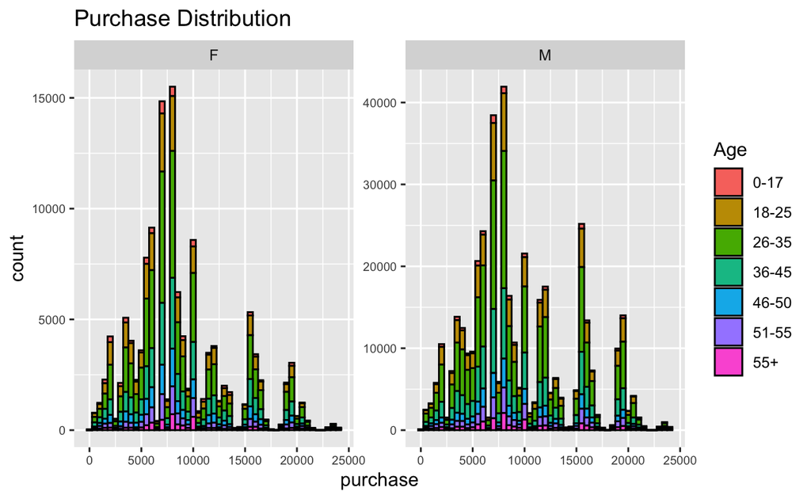

```r
ggplot(data, aes(Purchase, fill = Age)) +
  geom_histogram(color = "black", binwidth = 500)+
  labs(title = "Purchase Distribution",x = "purchase", y="count") +
  theme(axis.text=element_text(size = 7)) +
  facet_wrap(vars(Gender), scales = "free")
```

However,in this visualization graph, both men and women have abnormally high values at 15000, but abnormally low values around 15000. But it is hard to analyze the reason behind it from the data, so it is hard to answer.

### Consumer Favorite Product Category

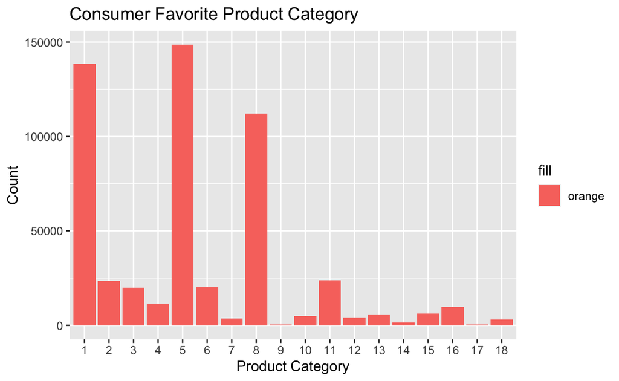

```r
PC_group<-data %>%
  group_by(Product_Category_1) %>%
  count()
ggplot(PC_group, aes(x = reorder(Product_Category_1,n),
                     y = n,
                     fill = "orange")) +
  geom_col(aes(factor(Product_Category_1)))+
  labs(x ="Product Category",
       y = "Count",
       title = "Consumer Favorite Product Category")
```

### Different Gender’s Preference for Various Products

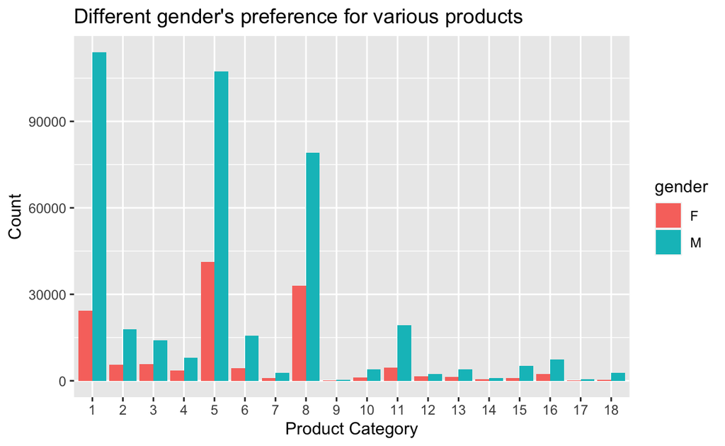

```r
G_P_group <- data %>%
  group_by(Gender,Product_Category_1) %>%
  count()
  ggplot(G_P_group, aes(x = as.factor(Product_Category_1),
         y = n,
         fill = as.factor(Gender)))+
  geom_bar(stat = "identity", position = "dodge")+
  labs(x="Product Category",y="Count",fill="gender",
       title="Different gender's preference for various products")
```

Among the preferences of different genders for each product, male consumers are generally higher than female, with No. 1 being the most significant.

### Average Consumer Price by Category

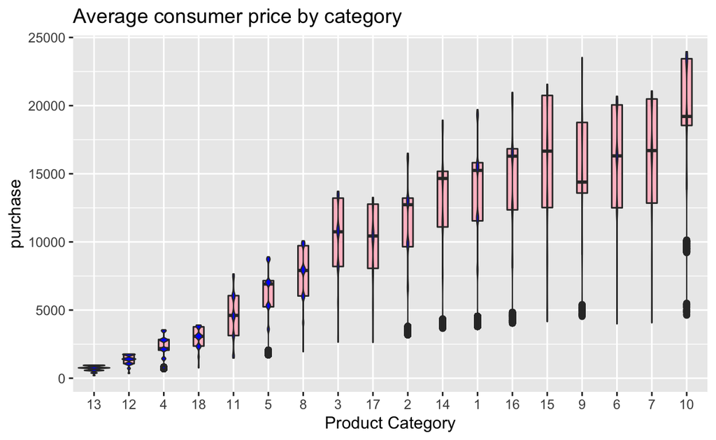

```r
#Average consumer price by category
  ggplot(data, aes(x = reorder(as.factor(Product_Category_1),Purchase),
                  y = Purchase))+
  geom_boxplot(fill = "pink", width = .3)+
  geom_violin(fill = "blue",size = .4)+
  labs(title = "Average consumer price by category",
       x = "Product Category",
       y = "purchase")
```

The image shows that the average consumption of each category, the price of category 10 is the highest, and the distribution is significantly asymmetric.

## Conclusion

This data analysis makes a basis for merchants to support the preparation of the shopping festival and provide personalized service solutions for which customer groups to better gain profit.

## Reflection

It is very important for an engineering student to learn how to handle data. This was my first exposure to a data science-related course, and since I had studied other programming languages, R was not new to me. However, R is a powerful language with many efficient libraries, and it takes a long time to learn and practice to use it proficiently. Through this course, I gradually mastered some basic usage of R and tried to analyze a database. I encountered a lot of confusion and difficulties in this process, but when I tried to solve them, I found that my data analysis ability has improved greatly.

## Bibliography

Wickham, H. & Grolemund, G. (n.d.). R for data science [eBook edition]. O’Reilly. https://r4ds.had.co.nz/index.html

Wickham, H., François, R., Henry, L., & Müller, K. (n.d.). Programming with dplyr. dplyr. https://dplyr.tidyverse.org/articles/programming.html

Kabacoff, R. (2020). Data visualizations with R. Quantitative Analysis Center, Wesleyan University. https://rkabacoff.github.io/datavis/index.html